# 住宅価格と子ども数

岩田真一郎（神奈川大学経済学部）

2023-02-6作成，2024-03-10改訂

［PDF形式：265KB］

岸田首相は$2023$年$1$月$31$日の衆院予算委員会の席で，少子化対策の一環として子育て世帯への住宅支援の必要性を述べました．これに反応して堀・福山（$2023$）は同年$2$月$1$日の日本経済新聞にて，「住宅の価格高騰と狭さが子どもを産もうとする心理を冷やしている」という興味深い記事を執筆しています．

子育て費用に含まれない住宅価格がなぜ家計の子ども数に影響を与えるのでしょうか？これは，子ども数と住宅消費（広さ）が関連すると考えられるからです．住宅価格（面積あたり）が低下すると，**需要法則**（需要曲線は右下がり）に従い家計は住宅面積を拡大します．家計の中には，住宅への支出（住宅価格×住宅面積）を以前より押さえて，子育てに必要なスペースを確保する家計も現れるでしょう．そして，住宅支出で押さえた予算を用いて実際に子ども数を増やす家計も現れるかもしれません．[^1]このように，ある財の価格が低下（上昇）したときに，別の財の需要が増える（減る）関係にあるとき，別の財はある財の**補完財**とよばれます．子どもを財と捉えることに違和感を覚えることもあると思います．そのときは，子どもと住宅は互いに補完関係にあると考えるといいでしょう．ただし，この関係は賃貸世帯については当てはまる可能性がありますが，持ち家世帯には当てはまらない可能性があります．以下ではこのことを説明します．

説明の前に，家賃と子ども数の関係をオープンデータで確認しておきましょう．図$1$は，[都道府県・市区町村のすがた（社会・人口統計体系）](https://www.e-stat.go.jp/regional-statistics/ssdsview)の市区町村データを用いて，東京都$23$区，県庁所在市，政令指定都市，中核市の家賃（円，$2013$年度の専用住宅の$1$畳あたり）と居住室畳数（借家$1$住宅あたり）の関係（$\rm{A}$）と，家賃と$0$～$5$歳人口（$2015$年度，$18$～$39$歳女性人口あたり）の関係（$\rm{B}$）をプロットしています．ただし，子ども数については，データの制約上，賃貸世帯と持ち家世帯を区別していまん．家賃の高い範囲でばらつきはありますが，家賃が$5000$円より低くなると，住宅面積（居住畳数）は大きくなり，子ども数も増加する傾向にあることがうかがえます．家賃と子ども数には負の相関関係がありそうです．

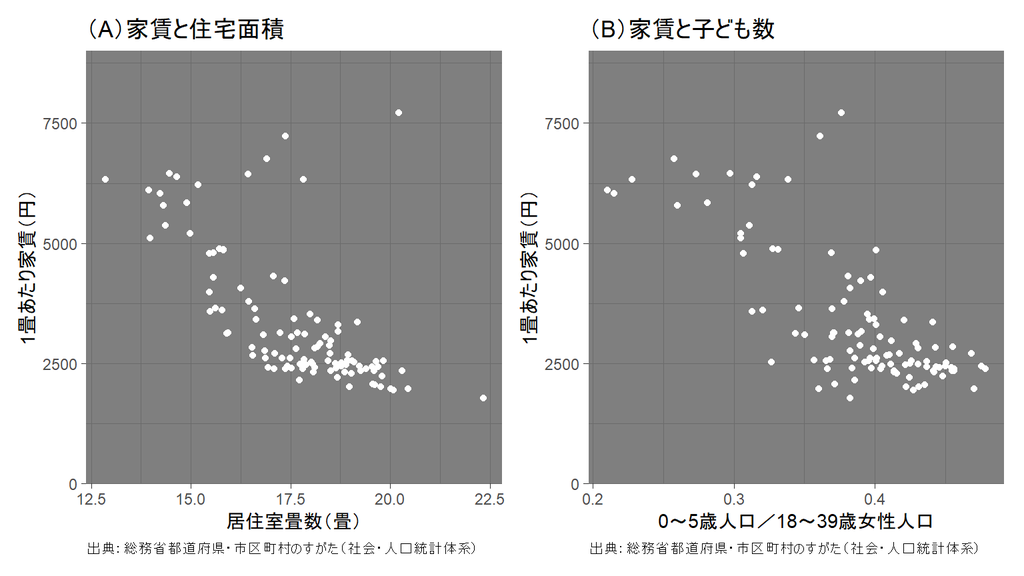

図1：東京都23区，県庁所在市，政令指定都市，中核市の子どもと住宅面積の補完関係

そこで，本稿の第$1$節から第$2$節（$1$），（$2$）では，家賃の低下が賃貸世帯の子ども数を増やす場合があることを消費者行動の理論を応用して説明します．続く，第$2$節（$3$）では，そのようなことが常に起きるわけではないことについて説明します．最後に，第$3$節では，住宅（所有）価格の低下が持ち家世帯の子ども数を減らす場合があることを説明します．

# 1 賃貸世帯の子ども数と住宅面積の決定

第$1$節から第$2$節では家計として賃貸世帯を取り上げます．家計（賃貸世帯）の子ども数と賃貸住宅の大きさ（住宅面積）の決定は，ミクロ経済学で学ぶ消費者行動の理論を応用して考えることができます（水谷，$2012$）．

家計は子ども数$k$と住宅面積$h$の組み合わせを決定するとしましょう．住宅の面積あたり賃貸価格（例えば図$1$では$1$畳あたり家賃を扱いました．以下では，住宅面積あたり賃貸価格を単に家賃とよぶことにします．）を$r$と表すと，住宅消費への支出は$rh$で表せます．ここで，$r$の値を$r_0$としましょう．後ほど，このパラメーター$r$の値を変更して，家計が選択する子ども数$k$と住宅面積$h$の組み合わせがどのように変化するのかを分析します．一方，子どもの価格は子育て費用で代理しましょう．子育て費用自体，家計は決定することができますが，ここでは一人あたり子育て費用は固定されており，家計はこの費用を与えられたものとして，子ども数を決定すると仮定します．ここで，一人あたりの子育て費用（以下，単に子育て費用とよぶことにします．）を$c$で表すと，子どもへの支出は$ck$で表せます．家計は与えられた所得$y$を用いて，子どもと住宅への支出をまかないます．このとき，家計の**予算制約式**は$(\ref{bc})$式のように表現できます．

$$y=ck+r_0h \label{bc}\tag{1}$$
$(\ref{bc})$式を子ども数$k$について解くと，$(\ref{b0})$式を得ます．

$$k=-\frac{r_0}{c}h+\frac{y}{c} \label{b0}\tag{2}$$

縦軸に$k$，横軸に$h$をそれぞれとり，$(\ref{b0})$式を描くと，予算制約線は，図$2$のように，縦軸の切片が$y/c$，傾きがマイナス$r_0/c$の右下がりの直線になります．したがって，予算制約線の傾きの絶対値は**相対価格**$r_0/c$に等しくなります．

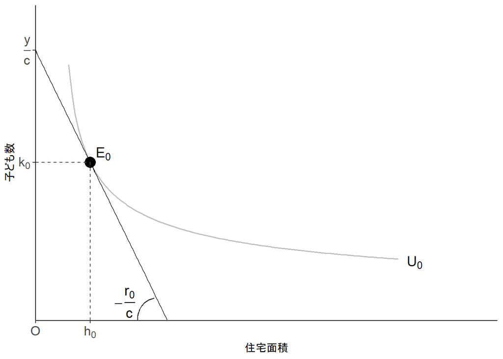

図2：家計の子ども数と住宅面積の決定

家計はこの予算制約線上で最も満足，効用，が高くなる組み合わせを選択します．[都市内の住宅立地](https://shinichiro-iwata.github.io/lecture-notes-urban-econ/residential-location-choice.html)でも述べたように，そのような最適な組み合わせは無差別曲線と予算制約線が接する（予算制約線上で限界代替率と相対価格が等しくなる）点，$E_0$点，でもとめられます．$E_0$点から家計は子ども数$k_0$，住宅面積$h_0$の組み合わせを選択することがわかります．

# 2 家賃低下と賃貸世帯の子ども数の変化

## （1）子ども数と住宅面積の補完関係

ここで，何らかのショック（例えば，政府の政策）で家賃が$r_0$から$r_2$に低下したとしましょう．このとき，予算制約線は$(\ref{b0})$式から次の$(\ref{b2})$式のように変化します．

$$k=-\frac{r_2}{c}h+\frac{y}{c} \label{b2}\tag{3}$$
所得$y$と子育て費用$c$は変化していないため，図$3$に示されるように縦軸の切片の値に変化はありません．一方，家賃の低下に伴い相対価格（予算制約線の傾きの絶対値）$r_2/c$は小さくなり，予算制約線は外側にシフトすることになります．この結果，最適点が$E_2$点に移動し，効用が$U_2$に高まります．家賃の低下は住宅面積の増加（$h_0$から$h_2$）をもたらします．同時に，家賃の低下は子ども数の増加（$k_0$から$k_2$）ももたらします．以上から，賃貸世帯では子ども数と住宅面積が補完関係にあることが確認できました．

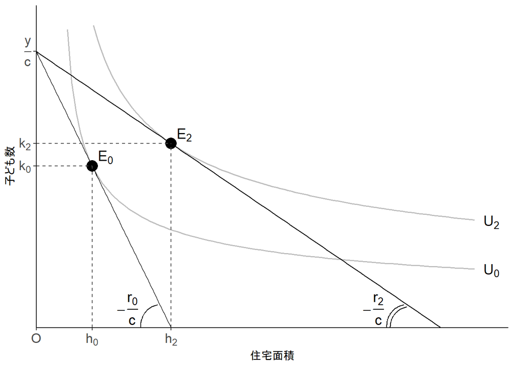

図3：家賃低下と子ども数の変化

## （2）代替効果と所得効果

それでは，家賃の低下は常に賃貸世帯の子ども数の増加をもたらすのでしょうか？このことを理解するためには，$E_0$点から$E_2$点への移動を**代替効果**と**所得効果**に分けることが有効です．

財・サービスの価格が低下すると，たとえが所得が変化しなくても，所得で買える財・サービスの量が増加します．実際に，図$3$において，家賃の低下が子ども数の増加をもたらしたのは，家賃の低下が賃貸世帯の購買力を上昇させたからです．この購買力変化の効果を所得効果とよびます．

所得効果の大きさを測るには工夫が必要になります．家賃の低下に伴い購買力が上昇すると，図$3$に見られるように，家計の効用は$U_0$から$U_2$に上昇します．そこで，新しい相対価格（$r_2/c$）の下での購買力上昇の影響を打ち消すために，予算制約線を元の無差別曲線$U_0$に接するように人為的に左方シフトさせましょう（ミクロ経済学で学んだように，所得が減少すると予算制約線は平行に左方シフトします．）．左方シフトした予算制約線は図$4$の破線のように表現されます．この破線の予算制約線は，$E_1$点で元の無差別曲線$U_0$に接しています．

$E_1$点においては，家賃が低下していても，効用水準は$U_0$のままのため，賃貸世帯は購買力上昇の実感を得られないはずです．すなわち，$E_0$点から$E_1$点の動きは，購買力上昇の影響が打ち消された相対価格の変化に基づく最適点の変化になります．これを代替効果とよびます．賃貸世帯は，代替効果を通じて，安くなった住宅面積を増やし（$h_0$$→$$h_1$），（相対的に高くなった）子ども数を減らす（$k_0$$→$$k_1$）ことがわかります．

一方，$E_1$点から$E_2$点の動きは，新しい相対価格の下で，所得が増加したことによる最適点の変化，すなわち所得効果を捉えています．図$4$では，賃貸世帯は，所得効果を通じて，住宅面積を増やす（$h_1$$→$$h_2$）だけでなく，子ども数も増やします（$k_1$$→$$k_2$）．これは子どもが**上級財**（所得が増えると財の需要が増える財）であることを意味します．

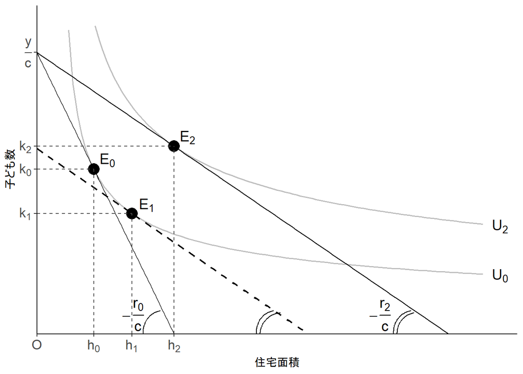

図4：代替効果と所得効果

以上から，家賃低下によって子どもの数が増えるのは，代替効果を通じた子ども数の減少を打ち消すほど所得効果を通じた子ども数の増加が大きいからだと分かります．住宅政策によって賃貸世帯の子ども数が増えるかどうかの鍵は所得効果の大きさが握っています．

## （3）所得効果を弱める要因

経済学者は必ずしも住宅面積と子ども数が補完関係になるとは考えていません．たとえ所得効果を通じて子ども数が増加しても，代替効果を通じた子ども数の減少が大きければ，結果として子ども数は減少してしまいます．これは，住宅面積と子ども数が**代替**関係にあることを意味します．

所得効果を弱める要因はどのようなものでしょうか？この節では図$2$から図$4$の一連の分析に含まれない要因ついて考えてみましょう．その代表例がベーカー（$\rm{Becker}$ $\&$ $\rm{Lewis,}$ $1973$）の考えた子どもの「質」に対する需要の存在です．ベッカーは，家計は子どもの量だけではなく，子どもの質からも効用を得ると考えました．そして，子どもの質は子どもへの支出（これまで固定してきた一人あたり子育て費用）で測れると仮定しました．このとき，家計は，仮に所得が上昇しても，子どもの数を増やすとは限りません．なぜなら，代わりに子どもの質を高める支出を増やすからかもしれないからです．山本（$2023$）は大都市は地方都市に比べて子どもの質を高める多種多様なサービスが供給されていると述べています．このため，大都市に居住する家計ほど，子どもの数を抑え，所得増加の機会に，子ども一人にかける支出を増やします．同じことが，家賃低下に伴う所得効果についてもいえるのです．

所得効果を弱める要因として，その他の財の存在もあげられます．大都市で教育サービスだけなく，その他の財やサービスに関しても多種多様です．山本（$2023$）は，大都市に居住する家計は，このような多種多様な財・サービスに増加した所得をつぎ込むため，子どもの数が少くなると言及しています．大都市では，魅力的な室内装飾品（家具，絵画），食器，家電商品などが住宅面積と補完関係になり，子どもとの関係を代替関係に追いやるかもしれません．

# 3 住宅価格と持ち家世帯の子ども数

これまで賃貸である家賃と子どもの数の関係について考えてきました．[住宅と住宅政策](https://shinichiro-iwata.github.io/lecture-notes-urban-econ/housing-price-and-policy.html)でも述べたように，家賃が低くなると，住宅を購入・所有する際に支払う住宅価格も低くなります．それでは，住宅価格が低くなると，子ども数は増えるでしょうか？理論的には，家賃低下とは異なり，子ども数を減らす可能性があります．なぜなら，持ち家世帯の場合，住宅価格の下落は，保有資産の目減りを意味するからです．例えば，自宅を担保としたときに受け取れる融資額も，自宅を売ったときに受け取れる売却額も，住宅価格下落時は減少します．資産の下落は，所得の下落と同様の影響を家計にもたらします．したがって，子どもが上級財の場合，住宅価格の低下は所得効果によって持ち家世帯の子どもの数を減らしてしまう可能性があります．実際に，水谷（$2012$）と岩田・直井（$2018$）は日本の家計データを用いてこのことを実証的に検証しています．

# 参考文献

- 岩田真一郎・直井道生（$2018$）「住宅価格の参照価格からの上昇と下落が出生行動に与える非対称な影響」『住宅土地経済』[第$109$号](http://www.hrf.or.jp/app/Display/popup/?table_id=table2&id=109)，$12-19$項
- 堀大介・福山絵里子（$2023$）[「住宅高騰，増やせぬ子ども 面積も狭く心理冷やす」](https://www.nikkei.com/article/DGXZQOUD26CKF0W3A120C2000000/)『日本経済新聞』$2023$年$2$月$1$日（朝刊・総合$2$面）
- 水谷徳子（$2012$）[「住宅価格の変化が出産に与える影響」](https://www.pdrc.keio.ac.jp/jpsc/wp-content/uploads/2018/05/096_04.pdf)『季刊家計経済研究』第$96$号，$24-34$項
- 山本和博（$2023$）[『大都市はどうやってできるのか』](https://www.chikumashobo.co.jp/product/9784480684356/)ちくまプリマー新書
- $\rm{Becker,}$ $\rm{G.}$ $\rm{S.}$ $\rm{and}$ $\rm{Lewis,}$ $\rm{H.}$ $\rm{G.}$ $(1973)$ [$\rm{On}$ $\rm{the}$ $\rm{interaction}$ $\rm{between}$ $\rm{the}$ $\rm{quantity}$ $\rm{and}$ $\rm{quality}$ $\rm{of}$ $\rm{children,}$](https://www.jstor.org/stable/1840425) $\rm{Journal}$ $\rm{of}$ $\rm{Political}$ $\rm{Economy}$ $\rm{81(2)}$ $\rm{pp.}$ $\rm{S219-S288}$

# R環境

**セッション情報**

- R version 4.1.3 (2022-03-10)
  - RStudio 2022.07.1+554
  - rmarkdown_2.19

**使用したパッケージ**

- `tidyverse`

# リンク

- [都市経済学講義ノート](https://shinichiro-iwata.github.io/lecture-notes-urban-econ/)
  - [住宅価格と住宅政策](https://shinichiro-iwata.github.io/lecture-notes-urban-econ/housing-price-and-policy.html)
  - [都市内の住宅立地](https://shinichiro-iwata.github.io/lecture-notes-urban-econ/residential-location-choice.html)
- [Rによる地理空間データの可視化](https://shinichiro-iwata.github.io/geospatial-data-visualization/)
- [Shinichiro Iwata](https://shinichiro-iwata.github.io/)

**アイコン**

- Font Awesome 6.3.0
[^1]: ある財の価格が変化したときに，その財への支出が増減するか否かは**需要の弾力性**に依存します．価格$1$％下落したときに，需要量の増加が$1$％より小さければ（需要の価格弾力性が$1$より小さければ），その財への支出は抑えられることを意味します．総務省『家計調査』では家賃は[基礎的支出](https://www.stat.go.jp/data/kakei/kou27/dan27.html)（必需品的なもの）に分類されます．経済学では，このように必需品に対する需要の価格弾力性は小さい傾向にあると考えます．